# Project by Omar Salah

This data set includes information about individual rides made in a bike-sharing system covering the greater San Francisco Bay area.

# Imports Libraries

```python
import numpy as np
import pandas as pd
import matplotlib.pyplot as plt
import seaborn as sns

sns.set(rc={'figure.figsize': [10, 10]}, font_scale=1.3)
```

# Read the Dataset

```python
df = pd.read_csv('201902-fordgobike-tripdata.csv')
print(df.shape)
df.head()
```

```
(183412, 16)
```

|  | duration_sec | start_time | end_time | start_station_id | start_station_name | start_station_latitude | start_station_longitude | end_station_id | end_station_name | end_station_latitude | end_station_longitude | bike_id | user_type | member_birth_year | member_gender | bike_share_for_all_trip |
| --- | --- | --- | --- | --- | --- | --- | --- | --- | --- | --- | --- | --- | --- | --- | --- | --- |
| 0 | 52185 | 2019-02-28 17:32:10.1450 | 2019-03-01 08:01:55.9750 | 21.0 | Montgomery St BART Station (Market St at 2nd St) | 37.789625 | -122.400811 | 13.0 | Commercial St at Montgomery St | 37.794231 | -122.402923 | 4902 | Customer | 1984.0 | Male | No |
| 1 | 42521 | 2019-02-28 18:53:21.7890 | 2019-03-01 06:42:03.0560 | 23.0 | The Embarcadero at Steuart St | 37.791464 | -122.391034 | 81.0 | Berry St at 4th St | 37.775880 | -122.393170 | 2535 | Customer | NaN | NaN | No |
| 2 | 61854 | 2019-02-28 12:13:13.2180 | 2019-03-01 05:24:08.1460 | 86.0 | Market St at Dolores St | 37.769305 | -122.426826 | 3.0 | Powell St BART Station (Market St at 4th St) | 37.786375 | -122.404904 | 5905 | Customer | 1972.0 | Male | No |
| 3 | 36490 | 2019-02-28 17:54:26.0100 | 2019-03-01 04:02:36.8420 | 375.0 | Grove St at Masonic Ave | 37.774836 | -122.446546 | 70.0 | Central Ave at Fell St | 37.773311 | -122.444293 | 6638 | Subscriber | 1989.0 | Other | No |
| 4 | 1585 | 2019-02-28 23:54:18.5490 | 2019-03-01 00:20:44.0740 | 7.0 | Frank H Ogawa Plaza | 37.804562 | -122.271738 | 222.0 | 10th Ave at E 15th St | 37.792714 | -122.248780 | 4898 | Subscriber | 1974.0 | Male | Yes |

# Data Wrangling

```python
df.info()
```

```
<class 'pandas.core.frame.DataFrame'>
RangeIndex: 183412 entries, 0 to 183411
Data columns (total 16 columns):
 #   Column                   Non-Null Count   Dtype
---  ------                   --------------   -----
 0   duration_sec             183412 non-null  int64
 1   start_time               183412 non-null  object
 2   end_time                 183412 non-null  object
 3   start_station_id         183215 non-null  float64
 4   start_station_name       183215 non-null  object
 5   start_station_latitude   183412 non-null  float64
 6   start_station_longitude  183412 non-null  float64
 7   end_station_id           183215 non-null  float64
 8   end_station_name         183215 non-null  object
 9   end_station_latitude     183412 non-null  float64
 10  end_station_longitude    183412 non-null  float64
 11  bike_id                  183412 non-null  int64
 12  user_type                183412 non-null  object
 13  member_birth_year        175147 non-null  float64
 14  member_gender            175147 non-null  object
 15  bike_share_for_all_trip  183412 non-null  object
dtypes: float64(7), int64(2), object(7)
memory usage: 22.4+ MB
```

- there are data types incorrect

```python
df['start_time'] = pd.to_datetime(df['start_time'] , format = '%Y %m %d %H:%M:%S' , errors = 'coerce')
df['end_time'] = pd.to_datetime(df['end_time'] , format = '%Y %m %d %H:%M:%S' , errors = 'coerce')
```

```python
df.isnull().sum()
```

```
duration_sec                  0
start_time                    0
end_time                      0
start_station_id            197
start_station_name          197
start_station_latitude        0
start_station_longitude       0
end_station_id              197
end_station_name            197
end_station_latitude          0
end_station_longitude         0
bike_id                       0
user_type                     0
member_birth_year          8265
member_gender              8265
bike_share_for_all_trip       0
dtype: int64
```

```python
df.drop(columns = ['member_birth_year' , 'member_gender'] , axis = 1 , inplace = True)
```

```python
df['start_station_id'].fillna(df['start_station_id'].median() , inplace =True)
df['start_station_name'].fillna(df['start_station_name'].mode()[0] , inplace =True)
df['end_station_id'].fillna(df['end_station_id'].median() , inplace =True)
df['end_station_name'].fillna(df['end_station_name'].mode()[0] , inplace =True)
```

```python
df.isnull().sum()
```

```
duration_sec               0
start_time                 0
end_time                   0
start_station_id           0
start_station_name         0
start_station_latitude     0
start_station_longitude    0
end_station_id             0
end_station_name           0
end_station_latitude       0
end_station_longitude      0
bike_id                    0
user_type                  0
bike_share_for_all_trip    0
dtype: int64
```

- No Missing all clean

```python
sum(df.duplicated())
```

```
0
```

- No Duplicated Data

```python
df.describe()
```

|  | duration_sec | start_station_id | start_station_latitude | start_station_longitude | end_station_id | end_station_latitude | end_station_longitude | bike_id |
| --- | --- | --- | --- | --- | --- | --- | --- | --- |
| count | 183412.000000 | 183412.000000 | 183412.000000 | 183412.000000 | 183412.000000 | 183412.000000 | 183412.000000 | 183412.000000 |
| mean | 726.078435 | 138.553274 | 37.771223 | -122.352664 | 136.210188 | 37.771427 | -122.352250 | 4472.906375 |
| std | 1794.389780 | 111.724563 | 0.099581 | 0.117097 | 111.461551 | 0.099490 | 0.116673 | 1664.383394 |
| min | 61.000000 | 3.000000 | 37.317298 | -122.453704 | 3.000000 | 37.317298 | -122.453704 | 11.000000 |
| 25% | 325.000000 | 47.000000 | 37.770083 | -122.412408 | 44.000000 | 37.770407 | -122.411726 | 3777.000000 |
| 50% | 514.000000 | 104.000000 | 37.780760 | -122.398285 | 100.000000 | 37.781010 | -122.398279 | 4958.000000 |
| 75% | 796.000000 | 239.000000 | 37.797280 | -122.286533 | 235.000000 | 37.797320 | -122.288045 | 5502.000000 |
| max | 85444.000000 | 398.000000 | 37.880222 | -121.874119 | 398.000000 | 37.880222 | -121.874119 | 6645.000000 |

```python
from geopy.distance import great_circle
def dist_kilos(y):
    loc_1 = (y['start_station_latitude'],y['start_station_longitude'])
    loc_2 = (y['end_station_latitude'],y['end_station_longitude'])
    return great_circle(loc_1,loc_2).kilometers

df['dist_in_kilos'] = df.apply(dist_kilos , axis = 1)
```

```python
df.head()
```

|  | duration_sec | start_time | end_time | start_station_id | start_station_name | start_station_latitude | start_station_longitude | end_station_id | end_station_name | end_station_latitude | end_station_longitude | bike_id | user_type | bike_share_for_all_trip | dist_in_kilos |
| --- | --- | --- | --- | --- | --- | --- | --- | --- | --- | --- | --- | --- | --- | --- | --- |
| 0 | 52185 | 2019-02-28 17:32:10.145 | 2019-03-01 08:01:55.975 | 21.0 | Montgomery St BART Station (Market St at 2nd St) | 37.789625 | -122.400811 | 13.0 | Commercial St at Montgomery St | 37.794231 | -122.402923 | 4902 | Customer | No | 0.544709 |
| 1 | 42521 | 2019-02-28 18:53:21.789 | 2019-03-01 06:42:03.056 | 23.0 | The Embarcadero at Steuart St | 37.791464 | -122.391034 | 81.0 | Berry St at 4th St | 37.775880 | -122.393170 | 2535 | Customer | No | 1.743002 |
| 2 | 61854 | 2019-02-28 12:13:13.218 | 2019-03-01 05:24:08.146 | 86.0 | Market St at Dolores St | 37.769305 | -122.426826 | 3.0 | Powell St BART Station (Market St at 4th St) | 37.786375 | -122.404904 | 5905 | Customer | No | 2.704549 |
| 3 | 36490 | 2019-02-28 17:54:26.010 | 2019-03-01 04:02:36.842 | 375.0 | Grove St at Masonic Ave | 37.774836 | -122.446546 | 70.0 | Central Ave at Fell St | 37.773311 | -122.444293 | 6638 | Subscriber | No | 0.260739 |
| 4 | 1585 | 2019-02-28 23:54:18.549 | 2019-03-01 00:20:44.074 | 7.0 | Frank H Ogawa Plaza | 37.804562 | -122.271738 | 222.0 | 10th Ave at E 15th St | 37.792714 | -122.248780 | 4898 | Subscriber | Yes | 2.409305 |

- we are doing here data extraction and engineering for lat and long columns to make new columns for distance in kilos and that will help us in analyzing
- Now, Dataset is clean and ready for EDA

# Exploratory Data Analysis

# User types column

```python
df['user_type'].value_counts()
```

```
Subscriber    163544
Customer       19868
Name: user_type, dtype: int64
```

```python
df['user_type'].value_counts() * 100 / df.shape[0]
```

```
Subscriber    89.167557
Customer      10.832443
Name: user_type, dtype: float64
```

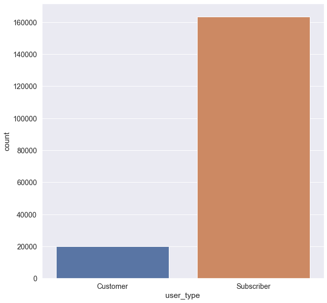

```python
sns.countplot( x = 'user_type' , data = df);
```

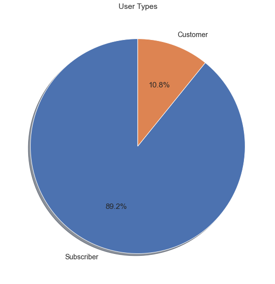

```python
data = df['user_type'].value_counts() * 100 / df.shape[0]
plt.pie(data , labels = data.index , autopct='%1.1f%%', shadow = 'True' , startangle = 90)
plt.title('User Types')
plt.show();
```

- we notice here more than 3/4 of the customers are subscribers

# The Measures Of The Duration of Rides

```python
df['duration_sec'].describe()
```

```
count    183412.000000
mean        726.078435
std        1794.389780
min          61.000000
25%         325.000000
50%         514.000000
75%         796.000000
max       85444.000000
Name: duration_sec, dtype: float64
```

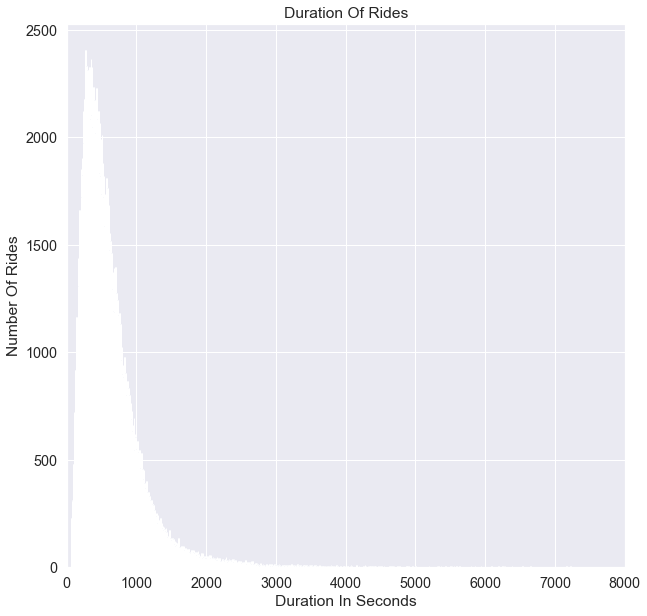

```python
data = df['duration_sec']
plt.hist(data , bins = 10000 , rwidth=.9)
plt.xlim(0,8000)
plt.title('Duration Of Rides')
plt.xlabel('Duration In Seconds')
plt.ylabel('Number Of Rides');
```

# Number of riders by hours

```python
df['hour'] = df['start_time'].dt.hour
```

```python
df.head()
```

|  | duration_sec | start_time | end_time | start_station_id | start_station_name | start_station_latitude | start_station_longitude | end_station_id | end_station_name | end_station_latitude | end_station_longitude | bike_id | user_type | bike_share_for_all_trip | dist_in_kilos | hour |
| --- | --- | --- | --- | --- | --- | --- | --- | --- | --- | --- | --- | --- | --- | --- | --- | --- |
| 0 | 52185 | 2019-02-28 17:32:10.145 | 2019-03-01 08:01:55.975 | 21.0 | Montgomery St BART Station (Market St at 2nd St) | 37.789625 | -122.400811 | 13.0 | Commercial St at Montgomery St | 37.794231 | -122.402923 | 4902 | Customer | No | 0.544709 | 17 |
| 1 | 42521 | 2019-02-28 18:53:21.789 | 2019-03-01 06:42:03.056 | 23.0 | The Embarcadero at Steuart St | 37.791464 | -122.391034 | 81.0 | Berry St at 4th St | 37.775880 | -122.393170 | 2535 | Customer | No | 1.743002 | 18 |
| 2 | 61854 | 2019-02-28 12:13:13.218 | 2019-03-01 05:24:08.146 | 86.0 | Market St at Dolores St | 37.769305 | -122.426826 | 3.0 | Powell St BART Station (Market St at 4th St) | 37.786375 | -122.404904 | 5905 | Customer | No | 2.704549 | 12 |
| 3 | 36490 | 2019-02-28 17:54:26.010 | 2019-03-01 04:02:36.842 | 375.0 | Grove St at Masonic Ave | 37.774836 | -122.446546 | 70.0 | Central Ave at Fell St | 37.773311 | -122.444293 | 6638 | Subscriber | No | 0.260739 | 17 |
| 4 | 1585 | 2019-02-28 23:54:18.549 | 2019-03-01 00:20:44.074 | 7.0 | Frank H Ogawa Plaza | 37.804562 | -122.271738 | 222.0 | 10th Ave at E 15th St | 37.792714 | -122.248780 | 4898 | Subscriber | Yes | 2.409305 | 23 |

```python
x = df['hour'].value_counts()
x.sort_values(ascending = False)
```

```
17    21864
8     21056
18    16827
9     15903
16    14169
7     10614
19     9881
15     9174
12     8724
13     8551
10     8364
14     8152
11     7884
20     6482
21     4561
6      3485
22     2916
23     1646
0       925
5       896
1       548
2       381
4       235
3       174
Name: hour, dtype: int64
```

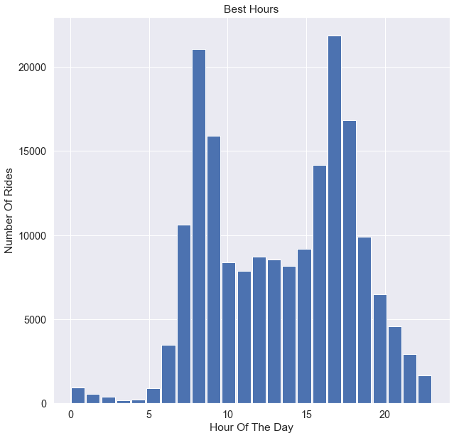

```python
data = df['hour']
plt.hist(data,rwidth=.9, bins = 24)
plt.title('Best Hours')
plt.xlabel('Hour Of The Day')
plt.ylabel('Number Of Rides');
```

- there are two peak intervals the first from 4 PM : 6 Pm and the second from 7 Am : 9 Am

# Number of riders by days

```python
df['day'] = df['start_time'].dt.day_name()
```

```python
df['day'].value_counts()
```

```
Thursday     35197
Tuesday      31813
Wednesday    29641
Friday       28981
Monday       26852
Sunday       15523
Saturday     15405
Name: day, dtype: int64
```

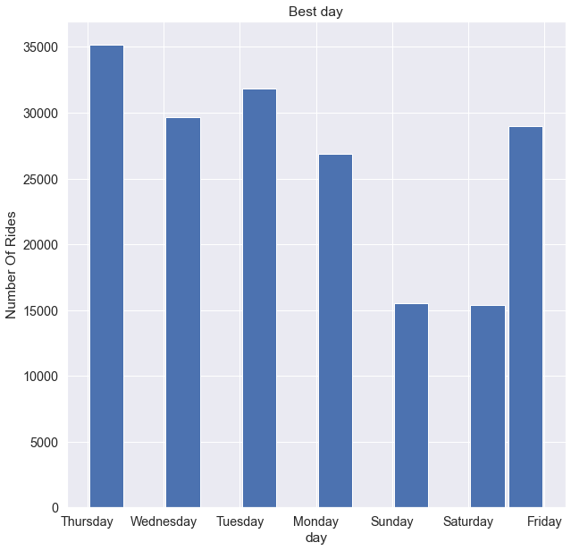

```python
data = df['day']
plt.hist(data,rwidth=.9, bins = 12)
plt.title('Best day')
plt.xlabel('day')
plt.ylabel('Number Of Rides');
```

- we noice here in work days that's increasing and the best day is thusday and in holidays that's decreasing

# The relationship between Duration and user types

```python
best_interval = df[df['duration_sec'] < 2000]
```

[figure not shown]

```python
sns.boxplot(data =best_interval ,  x='user_type' , y='duration_sec')
plt.title('Duration and Users Types')
plt.xlabel('Duration In Seconds')
plt.ylabel('Users Types');
```

- the customer are the best...they take long ride more than subscriber

# The Relationship Distance and the user types

[figure not shown]

```python
sns.barplot(data = df , x = 'user_type' , y = 'dist_in_kilos')
plt.title('Distance and Users Types')
plt.xlabel('Duration In Seconds')
plt.ylabel('Distance in kilos');
```

- as we expected customers are the most but with a bit difference

# the relationship between the day and duration in sec

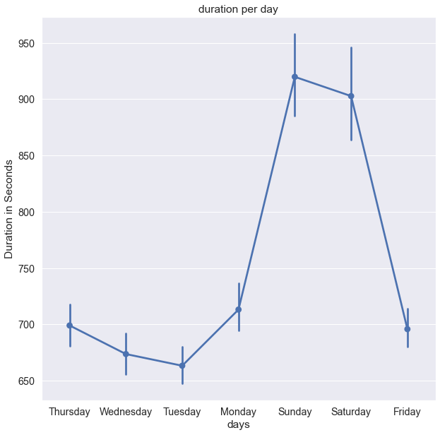

```python
ax = sns.pointplot(data=df , x='day' , y='duration_sec')
plt.xlabel('days')
plt.ylabel('Duration in Seconds')
plt.title('duration per day');
```

- we notice here the opposite of univariate of meaning the increasing and decreasing, here in holidays the longest ride in sunday and the shortest in the work day but it's make sense